# MTDT_Function_ClassifyR

Andy Wang & Jamie Mickaill

01/02/2022

# Multi Tier Decision Tree for Clinical Diagnostics

This program aims to use a sequential, machine learning approach to build a forest of multi-level clinical diagnostic trees with multi-omics data. This will allow for comparison of the cost and accuracy of different diagnostic sequences. With this information, we hope to enable better informed decisions of diagnostic processes.

At each node of the tree, a machine learning model is used to establish the sample specific accuracy of health outcome predictions for a single layer of the multi-omics data (e.g. how accurate is the prediction for a single individual based on their histology data?). If the prediction can not be made with sufficient accuracy, the individual will progress to the next level where an alternative model and layer of the omics data will be used. Currently each layer is analysed seperately, such that we have analysis of multiple single-omics datasets (ensemble learning to be implemented ?)

# Demonstration of MTDT function for ClassifyR

Below we create a mock MAE, assign some example runTest() parameters, and pass it to our GeneralMTDT() function. We then generate plots with the resulting data.

# Mock Dataset

```r
#Mock Dataset



############################################################################

  genesMatrix <- matrix(c(rnorm(90, 9, 1),
                         5.2, 5.3, 9.4, 9.4, 9.6, 9.9, 9.1, 9.8,9.5, 9.4),
              ncol = 10, byrow = TRUE)

  genesMatrix2 <- matrix(c(rnorm(90, 9, 1),
                         5.2, 5.3, 9.4, 9.4, 9.6, 9.9, 9.1, 9.8,9.5, 9.4),
              ncol = 10, byrow = TRUE)

    genesMatrix3 <- matrix(c(rnorm(90, 9, 1),
                         5.2, 5.3, 9.4, 9.4, 9.6, 9.9, 9.1, 9.8,9.5, 9.4),
              ncol = 10, byrow = TRUE)

  colnames(genesMatrix) <- paste("Sample", 1:10)
  rownames(genesMatrix) <- paste("Gene", 1:10)
    colnames(genesMatrix2) <- paste("Sample", 1:10)
  rownames(genesMatrix2) <- paste("Gene", 1:10)
      colnames(genesMatrix3) <- paste("Sample", 1:10)
  rownames(genesMatrix3) <- paste("Gene", 1:10)

  genders <- factor(c("Male", "Male", "Female", "Female", "Female",
                    "Female", "Female", "Female", "Female", "Female"))

  # Scenario: Male gender can predict the hard-to-classify Sample 1 and Sample 2.
  clinical <- DataFrame(Person_ID = c(1,2,3,4,5,6,7,8,9,10),
                        class = rep(c(1, 0), each = 5),
    age = c(31, 34, 32, 39, 33, 38, 34, 37, 35, 36),
                        gender = genders,

                row.names = colnames(genesMatrix))

  dataset <- MultiAssayExperiment(ExperimentList(RNA = genesMatrix, RNA2 = genesMatrix2, RNA3 = genesMatrix3), clinical)

  # colData(dataset)
  #                                                                                                                                 dataset = dataset[,"Sample 1",]


################################################################################
```

## Mock Inputs

Below is where the user can modify parameters of ClassifyR’s runTest/s() function

New features include

- First tier fixing
- Final tier retain-all
- Multiple Accuracy-threshold outputs

To be implemented

- Adjustable training params
- Parameter bounds (E.g. only display sequences < $x)
- Add Parameters (E.g. time, risk)
- Extensive error checking of inputs
- runTest() or runTests()

```r
#Mock Inputs

###############################################################################

#Main MAE
MultiAssayExperiment = dataset

#Properties for weighting
#Weights for properties
properties = c("TSA.retained", "Cost.Total")
weights = c(0.5,0.5)

#classificationNames - to be checked with classifyR docs
modelList = list("Easy-Hard", "Easy-Hard", "Easy-Hard")

#Not sure if this will be needed for runTests
rsmpList = list("rcv", "rcv", "boot")

#List of tiers
#Can probably use names(experiments(measurements)) + clinical for tiers
tierList = list("RNA1", "RNA2", "RNA3")

#Sample specific error cutoffs (E.g. x | if the sample specific error of cross validated prediction is > x, the sample will 'progress'to the next tier. Lower cutoff = higher retention generally)
ssercutoffList= list(c(0.4, 0.4, 0.4),c(0.45, 0.45, 0.45)) # -> to be implemented for multi-threshold analysis


#Tier costs
tierUnitCosts = c(100, 500, 1000)

#Which tier to fix as first in Tree? (If any)
#fixedTier = "Clinical"
# fixedTier = "RNA1"
fixedTier = NULL

#Model parameters?
selParams <- SelectParams(featureSelection = differentMeansSelection, selectionName = "Difference in Means",
                            resubstituteParams = ResubstituteParams(1:10, "balanced error", "lower"))

#runtest() or runtests()
runtestorruntests = "runtest"

#name of classifier column in dataset
classes = "class"

#other params
params = list(SelectParams(), TrainParams(), PredictParams())

#leave k out
leave = 2

#what percentage for training dataset (Not currently used)
percent=25

#Minimum overlap
minimumOverlapPercent = 80

#Validation method
validation = c("permute", "leaveOut", "fold")

#parallelization info
parallelParams = bpparam()

#EasyHard Params
easyDatasetID = "clinical"
hardDatasetID = names(MultiAssayExperiment)[1]
easyClassifierParams = list(minCardinality = 2, minPurity = 0.9)
hardClassifierParams = list(selParams, TrainParams(), PredictParams())


featureSets = NULL
metaFeatures = NULL
datasetName = "Test Data"


classificationName = "Easy-Hard"

training = 1:10
testing = 1:10

#Cross Validation inputs
k=5
permutations=100
rsmp=20


seed=1
verbose=3

###############################################################################
```

## Main Code

```
## [1] "(1) RNA1-RNA2-RNA3: <RNA1>"
```

```
## [1] "    Total = 10"
## [1] "    Processed = 10 (3 retained, 7 to progress to next tier)"
## [1] "    Not processed = 0"
## [1] "(1) RNA1-RNA2-RNA3: <RNA2>"
```

```
## [1] "    Total = 7"
## [1] "    Processed = 7 (3 retained, 4 to progress to next tier)"
## [1] "    Not processed = 0"
## [1] "(1) RNA1-RNA2-RNA3: <RNA3>"
```

```
## [1] "    Total = 4"
## [1] "    Processed = 4 (4 retained, 0 to progress to next tier)"
## [1] "    Not processed = 0"
## [1] "(2) RNA1-RNA3-RNA2: <RNA1>"
## [1] "    Total = 10"
## [1] "    Processed = 10 (3 retained, 7 to progress to next tier)"
## [1] "    Not processed = 0"
## [1] "(2) RNA1-RNA3-RNA2: <RNA3>"
```

```
## [1] "    Total = 7"
## [1] "    Processed = 7 (3 retained, 4 to progress to next tier)"
## [1] "    Not processed = 0"
## [1] "(2) RNA1-RNA3-RNA2: <RNA2>"
```

```
## [1] "    Total = 4"
## [1] "    Processed = 4 (4 retained, 0 to progress to next tier)"
## [1] "    Not processed = 0"
## [1] "(3) RNA2-RNA1-RNA3: <RNA2>"
## [1] "    Total = 10"
## [1] "    Processed = 10 (3 retained, 7 to progress to next tier)"
## [1] "    Not processed = 0"
## [1] "(3) RNA2-RNA1-RNA3: <RNA1>"
```

```
## [1] "    Total = 7"
## [1] "    Processed = 7 (3 retained, 4 to progress to next tier)"
## [1] "    Not processed = 0"
## [1] "(3) RNA2-RNA1-RNA3: <RNA3>"
```

```
## [1] "    Total = 4"
## [1] "    Processed = 4 (4 retained, 0 to progress to next tier)"
## [1] "    Not processed = 0"
## [1] "(4) RNA2-RNA3-RNA1: <RNA2>"
## [1] "    Total = 10"
## [1] "    Processed = 10 (3 retained, 7 to progress to next tier)"
## [1] "    Not processed = 0"
## [1] "(4) RNA2-RNA3-RNA1: <RNA3>"
```

```
## [1] "    Total = 7"
## [1] "    Processed = 7 (3 retained, 4 to progress to next tier)"
## [1] "    Not processed = 0"
## [1] "(4) RNA2-RNA3-RNA1: <RNA1>"
```

```
## [1] "    Total = 4"
## [1] "    Processed = 4 (4 retained, 0 to progress to next tier)"
## [1] "    Not processed = 0"
## [1] "(5) RNA3-RNA1-RNA2: <RNA3>"
## [1] "    Total = 10"
## [1] "    Processed = 10 (3 retained, 7 to progress to next tier)"
## [1] "    Not processed = 0"
## [1] "(5) RNA3-RNA1-RNA2: <RNA1>"
```

```
## [1] "    Total = 7"
## [1] "    Processed = 7 (3 retained, 4 to progress to next tier)"
## [1] "    Not processed = 0"
## [1] "(5) RNA3-RNA1-RNA2: <RNA2>"
```

```
## [1] "    Total = 4"
## [1] "    Processed = 4 (4 retained, 0 to progress to next tier)"
## [1] "    Not processed = 0"
## [1] "(6) RNA3-RNA2-RNA1: <RNA3>"
## [1] "    Total = 10"
## [1] "    Processed = 10 (3 retained, 7 to progress to next tier)"
## [1] "    Not processed = 0"
## [1] "(6) RNA3-RNA2-RNA1: <RNA2>"
```

```
## [1] "    Total = 7"
## [1] "    Processed = 7 (3 retained, 4 to progress to next tier)"
## [1] "    Not processed = 0"
## [1] "(6) RNA3-RNA2-RNA1: <RNA1>"
```

```
## [1] "    Total = 4"
## [1] "    Processed = 4 (4 retained, 0 to progress to next tier)"
## [1] "    Not processed = 0"
## [1] 0.4 0.4 0.4
## [1] "(1) RNA1-RNA2-RNA3: <RNA1>"
## [1] "    Total = 10"
## [1] "    Processed = 10 (4 retained, 6 to progress to next tier)"
## [1] "    Not processed = 0"
## [1] "(1) RNA1-RNA2-RNA3: <RNA2>"
```

```
## [1] "    Total = 6"
## [1] "    Processed = 6 (4 retained, 2 to progress to next tier)"
## [1] "    Not processed = 0"
## [1] "(1) RNA1-RNA2-RNA3: <RNA3>"
```

```
## [1] "    Total = 2"
## [1] "    Processed = 2 (2 retained, 0 to progress to next tier)"
## [1] "    Not processed = 0"
## [1] "(2) RNA1-RNA3-RNA2: <RNA1>"
## [1] "    Total = 10"
## [1] "    Processed = 10 (4 retained, 6 to progress to next tier)"
## [1] "    Not processed = 0"
## [1] "(2) RNA1-RNA3-RNA2: <RNA3>"
```

```
## [1] "    Total = 6"
## [1] "    Processed = 6 (4 retained, 2 to progress to next tier)"
## [1] "    Not processed = 0"
## [1] "(2) RNA1-RNA3-RNA2: <RNA2>"
```

```
## [1] "    Total = 2"
## [1] "    Processed = 2 (2 retained, 0 to progress to next tier)"
## [1] "    Not processed = 0"
## [1] "(3) RNA2-RNA1-RNA3: <RNA2>"
## [1] "    Total = 10"
## [1] "    Processed = 10 (4 retained, 6 to progress to next tier)"
## [1] "    Not processed = 0"
## [1] "(3) RNA2-RNA1-RNA3: <RNA1>"
```

```
## [1] "    Total = 6"
## [1] "    Processed = 6 (4 retained, 2 to progress to next tier)"
## [1] "    Not processed = 0"
## [1] "(3) RNA2-RNA1-RNA3: <RNA3>"
```

```
## [1] "    Total = 2"
## [1] "    Processed = 2 (2 retained, 0 to progress to next tier)"
## [1] "    Not processed = 0"
## [1] "(4) RNA2-RNA3-RNA1: <RNA2>"
## [1] "    Total = 10"
## [1] "    Processed = 10 (4 retained, 6 to progress to next tier)"
## [1] "    Not processed = 0"
## [1] "(4) RNA2-RNA3-RNA1: <RNA3>"
```

```
## [1] "    Total = 6"
## [1] "    Processed = 6 (4 retained, 2 to progress to next tier)"
## [1] "    Not processed = 0"
## [1] "(4) RNA2-RNA3-RNA1: <RNA1>"
```

```
## [1] "    Total = 2"
## [1] "    Processed = 2 (2 retained, 0 to progress to next tier)"
## [1] "    Not processed = 0"
## [1] "(5) RNA3-RNA1-RNA2: <RNA3>"
## [1] "    Total = 10"
## [1] "    Processed = 10 (4 retained, 6 to progress to next tier)"
## [1] "    Not processed = 0"
## [1] "(5) RNA3-RNA1-RNA2: <RNA1>"
```

```
## [1] "    Total = 6"
## [1] "    Processed = 6 (4 retained, 2 to progress to next tier)"
## [1] "    Not processed = 0"
## [1] "(5) RNA3-RNA1-RNA2: <RNA2>"
```

```
## [1] "    Total = 2"
## [1] "    Processed = 2 (2 retained, 0 to progress to next tier)"
## [1] "    Not processed = 0"
## [1] "(6) RNA3-RNA2-RNA1: <RNA3>"
## [1] "    Total = 10"
## [1] "    Processed = 10 (4 retained, 6 to progress to next tier)"
## [1] "    Not processed = 0"
## [1] "(6) RNA3-RNA2-RNA1: <RNA2>"
```

```
## [1] "    Total = 6"
## [1] "    Processed = 6 (4 retained, 2 to progress to next tier)"
## [1] "    Not processed = 0"
## [1] "(6) RNA3-RNA2-RNA1: <RNA1>"
```

```
## [1] "    Total = 2"
## [1] "    Processed = 2 (2 retained, 0 to progress to next tier)"
## [1] "    Not processed = 0"
## [1] 0.45 0.45 0.45
```

## Plots

Updates

- Accuracy instead of Error
- Changes axis on bubble plot (from y = retention to y = cost)

New plots

- Tree plot with numbers of samples progressed represented on edge lines

To implement

- Concentric bubbles to represent tier retention proportions
- Table -> remove proportion retained but keep total accuracy?

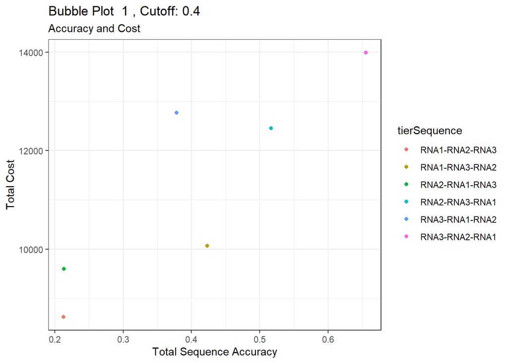

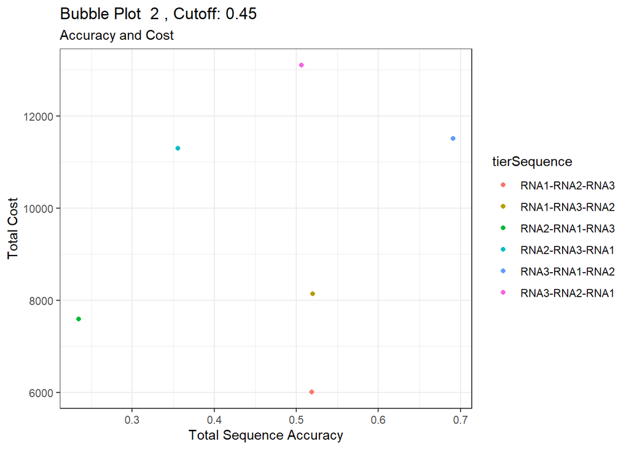

|  | Tier.Sequence | TSA.retained | N.Total | Threshold | Cost.byTier | Cost.Total | Weight |
| --- | --- | --- | --- | --- | --- | --- | --- |
| 1 | RNA1-RNA2-RNA3 | 0.575 | 10 | 0.4 | $1000-$3500-$4000 | 8500 | 0.0985199514783313 |
| 2 | RNA1-RNA3-RNA2 | 0.575 | 10 | 0.4 | $1000-$7000-$2000 | 10000 | 0.398672795478203 |
| 3 | RNA2-RNA1-RNA3 | 0.575 | 10 | 0.4 | $5000-$700-$4000 | 9700 | 0.338642226678229 |
| 4 | RNA2-RNA3-RNA1 | 0.575 | 10 | 0.4 | $5000-$7000-$400 | 12400 | 0.878917345877998 |
| 5 | RNA3-RNA1-RNA2 | 0.575 | 10 | 0.4 | $10000-$700-$2000 | 12700 | 0.938947914677972 |
| 6 | RNA3-RNA2-RNA1 | 0.575 | 10 | 0.4 | $10000-$3500-$400 | 13900 | 1.17907018987787 |
| 7 | RNA1-RNA2-RNA3 | 0.565 | 10 | 0.45 | $1000-$3000-$2000 | 6000 | -1.35916189627779 |
| 8 | RNA1-RNA3-RNA2 | 0.565 | 10 | 0.45 | $1000-$6000-$1000 | 8000 | -0.958958104277964 |
| 9 | RNA2-RNA1-RNA3 | 0.565 | 10 | 0.45 | $5000-$600-$2000 | 7600 | -1.03899886267793 |
| 10 | RNA2-RNA3-RNA1 | 0.565 | 10 | 0.45 | $5000-$6000-$200 | 11200 | -0.318632037078237 |

[output cut: 2 more lines]

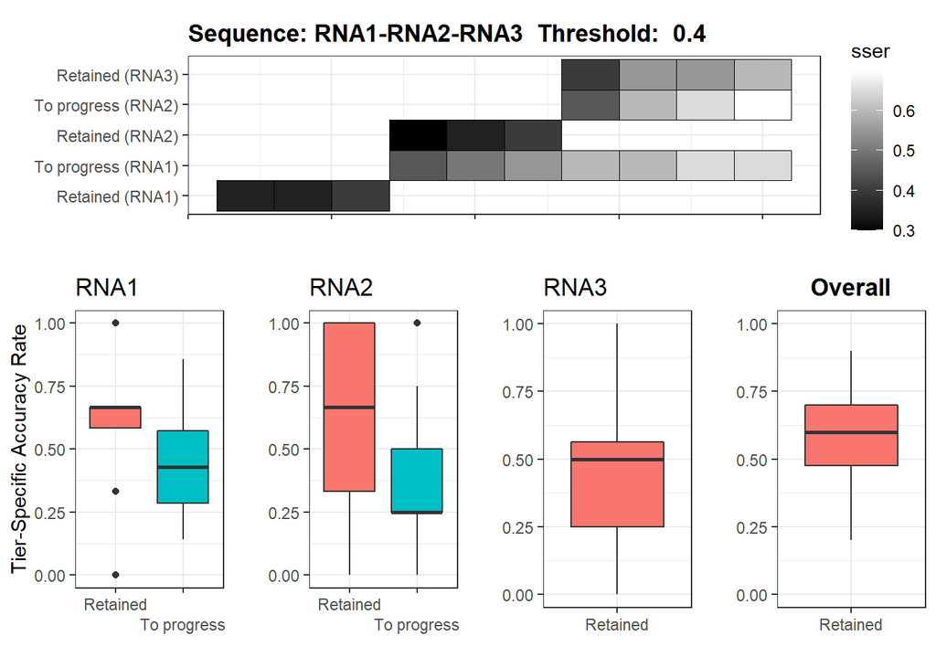

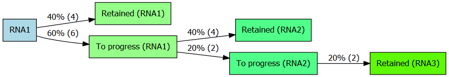

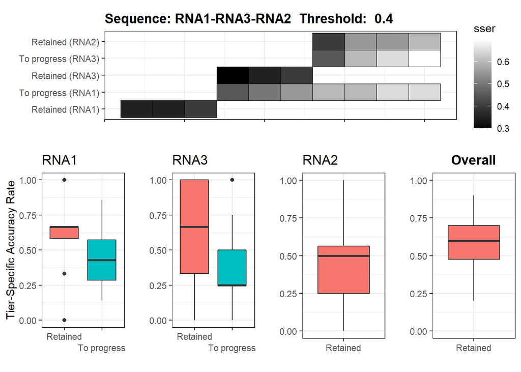

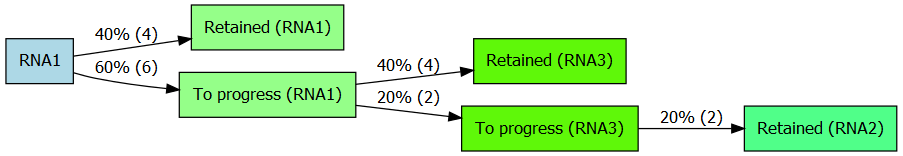

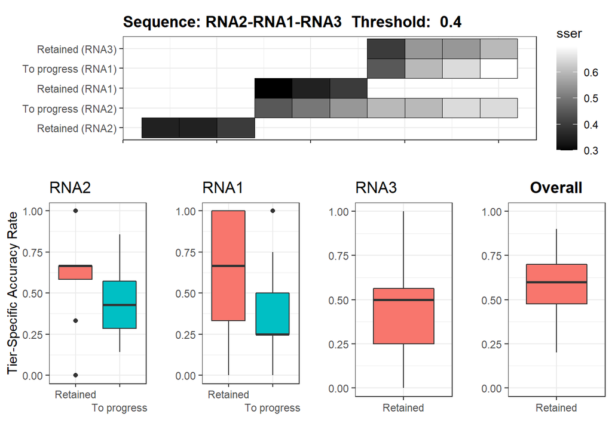

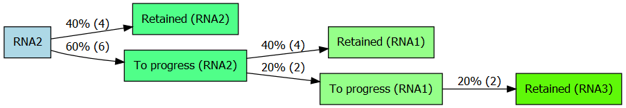

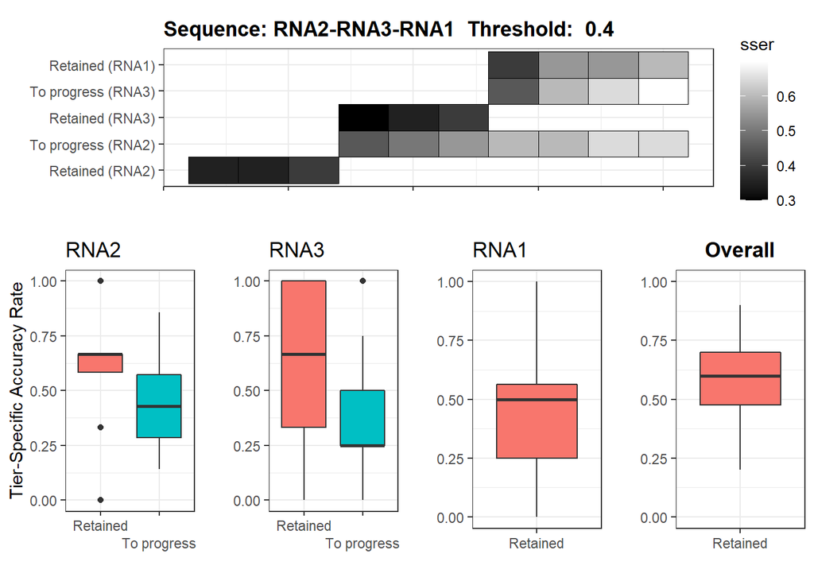

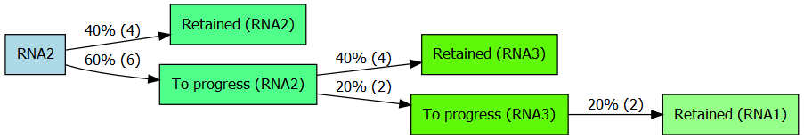

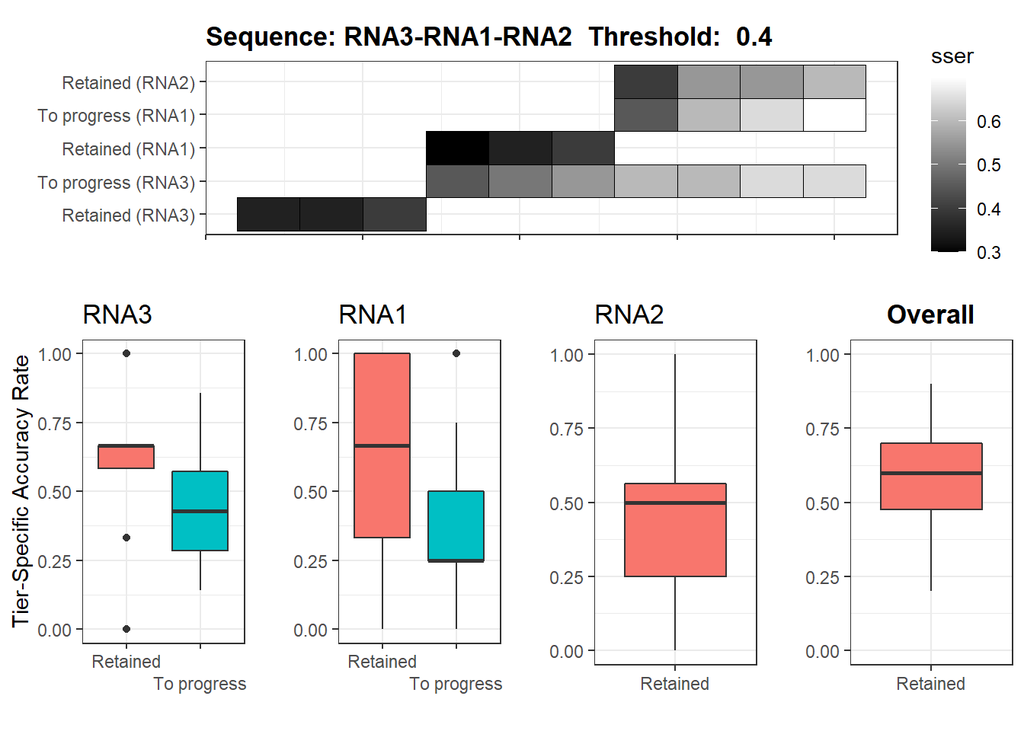

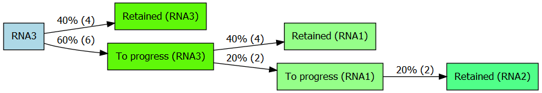

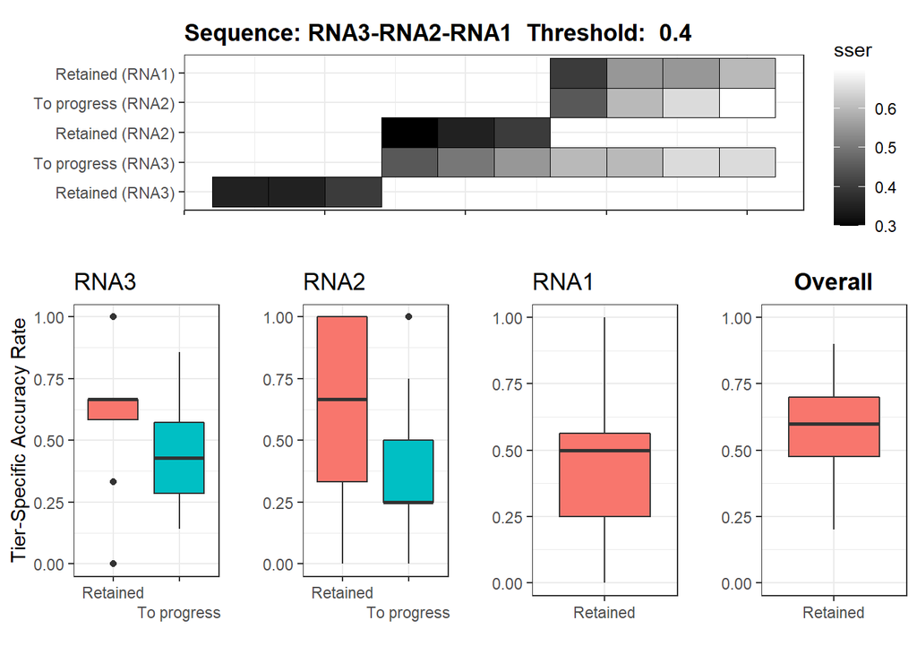

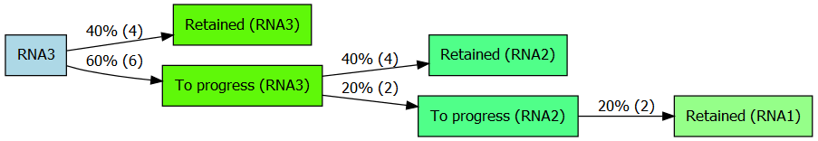

[12 more figures not shown]